# Obesity_Analysis

2024-06-10

#Data dictionary

Gender: Feature, Categorical, “Gender”

Age : Feature, Continuous, “Age”

Height: Feature, Continuous

Weight: Feature Continuous

family_history_with_overweight: Feature, Binary, ” Has a family member suffered or suffers from overweight? ”

FAVC : Feature, Binary, ” Do you eat high caloric food frequently? ”

FCVC : Feature, Integer, ” Do you usually eat vegetables in your meals? ”

NCP : Feature, Continuous, ” How many main meals do you have daily? ”

CAEC : Feature, Categorical, ” Do you eat any food between meals? ”

SMOKE : Feature, Binary, ” Do you smoke? ”

CH2O: Feature, Continuous, ” How much water do you drink daily? ”

SCC: Feature, Binary, ” Do you monitor the calories you eat daily? ”

FAF: Feature, Continuous, ” How often do you have physical activity? ”

TUE : Feature, Integer, ” How much time do you use technological devices such as cell phone, videogames, television, computer and others? ”

CALC : Feature, Categorical, ” How often do you drink alcohol? ”

MTRANS : Feature, Categorical, ” Which transportation do you usually use? ”

NObeyesdad : Target, Categorical, “Obesity level”

```r
head(obesitydf)
```

```
## # A tibble: 6 × 17
##     Age Gender Height Weight CALC       FAVC   FCVC   NCP SCC   SMOKE  CH2O
##   <dbl> <chr>   <dbl>  <dbl> <chr>      <chr> <dbl> <dbl> <chr> <chr> <dbl>
## 1    21 Female   1.62   64   no         no        2     3 no    no        2
## 2    21 Female   1.52   56   Sometimes  no        3     3 yes   yes       3
## 3    23 Male     1.8    77   Frequently no        2     3 no    no        2
## 4    27 Male     1.8    87   Frequently no        3     3 no    no        2
## 5    22 Male     1.78   89.8 Sometimes  no        2     1 no    no        2
## 6    29 Male     1.62   53   Sometimes  yes       2     3 no    no        2
## # ℹ 6 more variables: family_history_with_overweight <chr>, FAF <dbl>,
## #   TUE <dbl>, CAEC <chr>, MTRANS <chr>, NObeyesdad <chr>
```

```r
unique(obesitydf$NObeyesdad) #all possible values for the classification of obesity
```

```
## [1] "Normal_Weight"       "Overweight_Level_I"  "Overweight_Level_II"
## [4] "Obesity_Type_I"      "Insufficient_Weight" "Obesity_Type_II"
## [7] "Obesity_Type_III"
```

```r
summary(obesitydf)
```

```
##       Age           Gender              Height          Weight
##  Min.   :14.00   Length:2111        Min.   :1.450   Min.   : 39.00
##  1st Qu.:19.95   Class :character   1st Qu.:1.630   1st Qu.: 65.47
##  Median :22.78   Mode  :character   Median :1.700   Median : 83.00
##  Mean   :24.31                      Mean   :1.702   Mean   : 86.59
##  3rd Qu.:26.00                      3rd Qu.:1.768   3rd Qu.:107.43
##  Max.   :61.00                      Max.   :1.980   Max.   :173.00
##      CALC               FAVC                FCVC            NCP
##  Length:2111        Length:2111        Min.   :1.000   Min.   :1.000
##  Class :character   Class :character   1st Qu.:2.000   1st Qu.:2.659
##  Mode  :character   Mode  :character   Median :2.386   Median :3.000
##                                        Mean   :2.419   Mean   :2.686
##                                        3rd Qu.:3.000   3rd Qu.:3.000
##                                        Max.   :3.000   Max.   :4.000
##      SCC               SMOKE                CH2O
##  Length:2111        Length:2111        Min.   :1.000
##  Class :character   Class :character   1st Qu.:1.585
##  Mode  :character   Mode  :character   Median :2.000
##                                        Mean   :2.008
##                                        3rd Qu.:2.477
##                                        Max.   :3.000
##  family_history_with_overweight      FAF              TUE
##  Length:2111                    Min.   :0.0000   Min.   :0.0000
##  Class :character               1st Qu.:0.1245   1st Qu.:0.0000
##  Mode  :character               Median :1.0000   Median :0.6253
##                                 Mean   :1.0103   Mean   :0.6579
##                                 3rd Qu.:1.6667   3rd Qu.:1.0000
##                                 Max.   :3.0000   Max.   :2.0000
##      CAEC              MTRANS           NObeyesdad
##  Length:2111        Length:2111        Length:2111
##  Class :character   Class :character   Class :character
##  Mode  :character   Mode  :character   Mode  :character
##
##
##
```

# Predict Obesity Level

## Multinomial Logistic Regression

```r
obesitydf$NObeyesdad <- factor(obesitydf$NObeyesdad)
levels(obesitydf$NObeyesdad)
```

```
## [1] "Insufficient_Weight" "Normal_Weight"       "Obesity_Type_I"
## [4] "Obesity_Type_II"     "Obesity_Type_III"    "Overweight_Level_I"
## [7] "Overweight_Level_II"
```

```r
obesitydf$NObeyesdad <- relevel(obesitydf$NObeyesdad, ref="Normal_Weight")#use "Normal_Weight" as reference
```

### Feature Selection Using Stepwise Regression (Akaike Information Criterion)

```r
none <- multinom(NObeyesdad~1, data=obesitydf)
full <- multinom(NObeyesdad~., data=obesitydf)
step <- MASS::stepAIC(full, direction="both", trace=F)

# multinom(formula = NObeyesdad ~ Gender + Height + Weight + CALC +
#     FAVC + SCC + CH2O + family_history_with_overweight + FAF +
#     TUE, data = obesitydf)
```

Selected Model:

multinom(formula = NObeyesdad ~ Gender + Height + Weight + CALC + FAVC + SCC + CH2O + family_history_with_overweight + FAF + TUE, data = obesitydf)

```r
summary(step)
```

```
## Call:
## multinom(formula = NObeyesdad ~ Gender + Height + Weight + CALC +
##     FAVC + SCC + CH2O + family_history_with_overweight + FAF +
##     TUE, data = obesitydf)
##
## Coefficients:
##                     (Intercept)  GenderMale    Height    Weight CALCFrequently
## Insufficient_Weight  -257.51985   -2.203102  244.4792 -3.966457      51.136380
## Obesity_Type_I        320.17523   -7.229589 -547.3679  6.423778     112.572235
## Obesity_Type_II       287.10012   -1.691761 -785.2884 11.472995      93.473626
## Obesity_Type_III      -41.33494 -141.786123 -560.9878 12.107416       9.099508
## Overweight_Level_I    107.86526   -4.684353 -202.3618  2.534646      54.131848
## Overweight_Level_II   221.19824   -2.875545 -388.6103  4.615205      93.764361
##                        CALCno CALCSometimes     FAVCyes      SCCyes        CH2O
## Insufficient_Weight  51.44070      51.84774   1.9094890  -0.7326213   2.0183234
## Obesity_Type_I      112.30161     109.43719  -0.6867210  -3.9820677  -0.3915019
## Obesity_Type_II     107.45373      80.91397 -10.0986729 -30.7336492 -21.4497548
## Obesity_Type_III    -20.74650     -37.04235  24.7424380  -7.1866897 -11.1755692
## Overweight_Level_I   57.00627      57.25576   0.5176111   1.8899441  -0.9848413
## Overweight_Level_II  95.92650      93.07229  -1.7625033   1.4394637  -0.2829451
##                     family_history_with_overweightyes          FAF        TUE
## Insufficient_Weight                         1.9675755   0.06948678  -2.367060
## Obesity_Type_I                              2.4373854  -1.11916161   2.248930
## Obesity_Type_II                           -16.9089835 -11.36060129  -3.474607
## Obesity_Type_III                          -12.9650181  -3.81685406 -17.323766
## Overweight_Level_I                         -0.6260764  -0.02284606   1.333628
## Overweight_Level_II                         3.0437529  -0.52200286   2.368798
##
## Std. Errors:
##                     (Intercept) GenderMale   Height     Weight CALCFrequently
## Insufficient_Weight    3.157794   1.807154 2.703778 0.19643326       3.138793
## Obesity_Type_I         5.069352   2.069634 4.142091 0.17378186       2.682480
## Obesity_Type_II        2.921078   6.139942 5.273201 0.14426008       4.594066
## Obesity_Type_III       3.623734   9.305992 4.968816 0.19036564       4.008594
## Overweight_Level_I     2.633510   1.261186 2.448692 0.08946735       1.402473
## Overweight_Level_II    3.092454   1.476139 3.503330 0.12123052       1.595701
##                       CALCno CALCSometimes  FAVCyes   SCCyes      CH2O
## Insufficient_Weight 1.808678      1.622289 1.377463 2.069933 1.4671417
## Obesity_Type_I      1.954660      2.022175 1.808181 3.761132 1.0821966
## Obesity_Type_II     2.582518      2.845130 6.099711 4.299166 1.8698459
## Obesity_Type_III    9.280186      6.976449 7.032149 4.008594 6.5852800
## Overweight_Level_I  1.035379      1.021529 1.060169 1.081279 0.6446229
## Overweight_Level_II 1.264830      1.216470 1.314651 1.671458 0.8486827
##                     family_history_with_overweightyes       FAF       TUE
## Insufficient_Weight                         1.3870722 0.5991830 0.8981307
## Obesity_Type_I                              2.3173398 0.8375790 1.0539673
## Obesity_Type_II                             8.4760391 1.3431668 2.0209505
## Obesity_Type_III                            7.0321447 8.1749199 6.1657105
## Overweight_Level_I                          0.8320594 0.3994876 0.6221796
## Overweight_Level_II                         1.2045971 0.5947649 0.8165813
##
## Residual Deviance: 239.2909
## AIC: 395.2909
```

Reference level is “Normal_Weight” which means that every row (Insufficient_Weight…etc) is comparing to normal weight. For example, in the “Height” column in the coefficient table in the “Insufficient_Weight” row, the coefficient is 244 which indicates that for each increase in “Height”, you are more likely a “Insufficient_Weight” as opposed to a “Normal_Weight.” So in general, positive values in the coefficient table means that increase in a certain value increases the chance that you are the descriptor of that row and vice versa with negative values. The coefficients represent the change in the log-odds of the outcome for a one-unit increase in the predictor variable.

```r
head(prob <- fitted(step))
```

```
##   Normal_Weight Insufficient_Weight Obesity_Type_I Obesity_Type_II
## 1  8.807335e-01        6.073149e-27   8.048491e-18    1.617386e-90
## 2  9.078776e-01        6.509799e-22   6.223533e-22   9.633839e-144
## 3  9.999979e-01        3.370594e-31   2.784136e-28   9.468221e-104
## 4  2.676824e-06        7.993140e-54   5.434787e-08    1.210465e-50
## 5  2.691402e-15        1.610024e-69   8.202522e-05    1.865461e-34
## 6  9.999999e-01        1.023388e-07   3.594944e-55   4.577370e-153
##   Obesity_Type_III Overweight_Level_I Overweight_Level_II
## 1    9.095228e-109       1.192621e-01        4.412034e-06
## 2    5.872105e-139       9.212233e-02        1.132209e-07
## 3    3.854810e-136       2.089404e-06        5.449662e-13
## 4     5.619701e-76       2.806629e-01        7.193343e-01
## 5     4.205220e-82       4.644813e-04        9.994535e-01
## 6    2.627706e-211       1.033997e-15        1.115240e-33
```

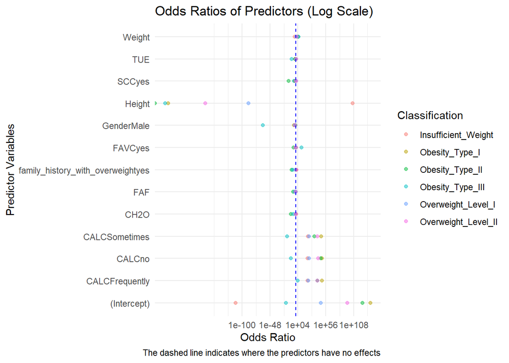

The points left of the blue dashed line indicate that the “increase” in that specific category will decrease the probability that the subject is classified as the classification indicated by the color. For example, in the “Height” row, the red dot is on the right of the blue line, which suggests that an increase in height will increase the possibility of someone being classified as “Insufficient_Weight.” We see a trend for the points on the left of the blue line that an increase in height will decrease the probability of someone being classified as one of the more big-boned categories.

### Cross Validation

```r
tc <- trainControl(method="cv", number =5)

model <- train(NObeyesdad ~ Gender + Height + Weight + CALC +
    FAVC + SCC + CH2O + family_history_with_overweight + FAF +
    TUE, data = obesitydf, method="multinom", trControl=tc)
```

```r
print(model)
```

```
## Penalized Multinomial Regression
##
## 2111 samples
##   10 predictor
##    7 classes: 'Normal_Weight', 'Insufficient_Weight', 'Obesity_Type_I', 'Obesity_Type_II', 'Obesity_Type_III', 'Overweight_Level_I', 'Overweight_Level_II'
##
## No pre-processing
## Resampling: Cross-Validated (5 fold)
## Summary of sample sizes: 1689, 1690, 1688, 1689, 1688
## Resampling results across tuning parameters:
##
##   decay  Accuracy   Kappa
##   0e+00  0.9644594  0.9584901
##   1e-04  0.9620987  0.9557339
##   1e-01  0.8446368  0.8184855
##
## Accuracy was used to select the optimal model using the largest value.
## The final value used for the model was decay = 0.
```

$$\kappa=\frac{p_o-p_e}{1-p_e}$$
where $p_o$ is accuracy and $p_e$ is the probability that the agreement between the predicted and true class labels are purely by chance.